# Exploratory Analysis - Sberbank

This is a simple EDA for the Sberbank data set.

The tabbed plotting approach is inspired by [this kernel](https://www.kaggle.com/damianpanek/data-exploration-in-r) from Damiano

## Sale Price

### Complete (with Outliers)

We can see two interesting things: 1) The distribution is skewed and 2) it has quite a long tail.

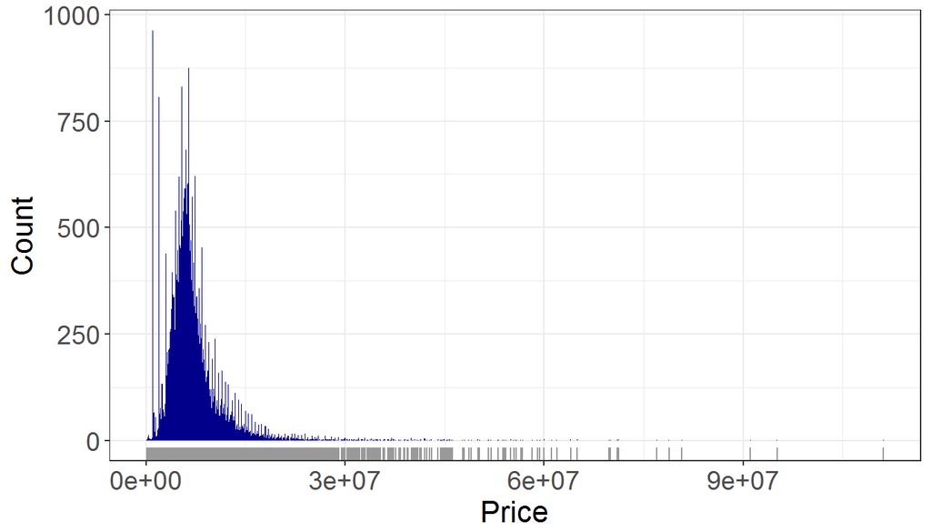

### Zoomed

When zooming closer one can clearly see the two spikes on the left side of the distribution. These seem to be popular sale prices. It might be worthwile, to later round predicted prices which are close to these values to exactly match these values.

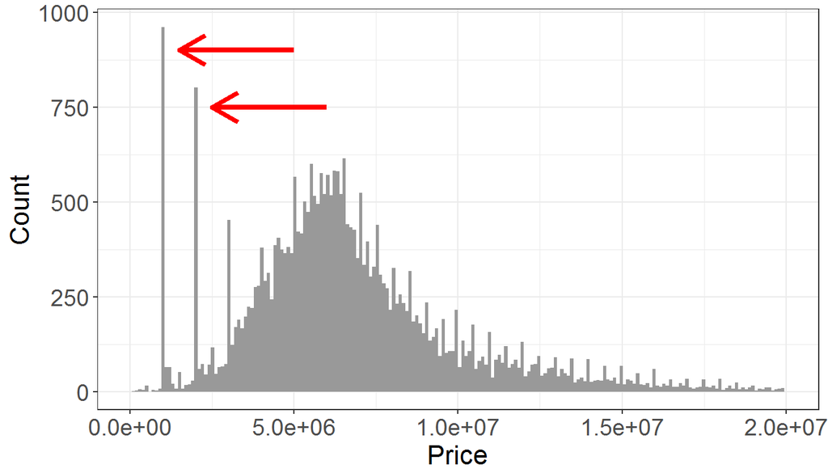

### Log Price

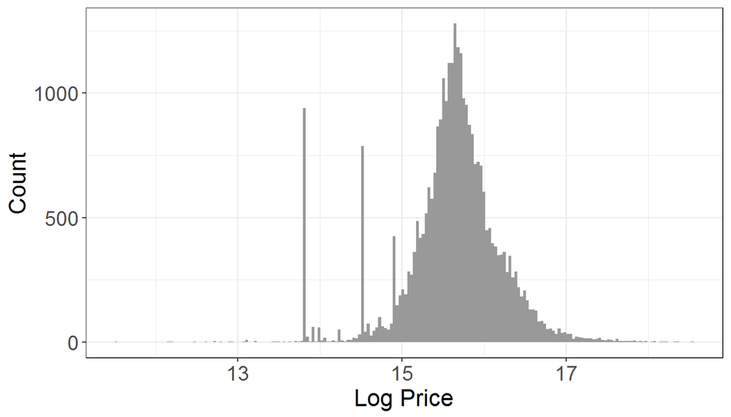

## Association of Variables with Sale Price

### Timestamp

Let’s first see, whether the sale price varies with the time point when the property was sold.

#### Per Year

We can see a clear upward trend across the recent years.

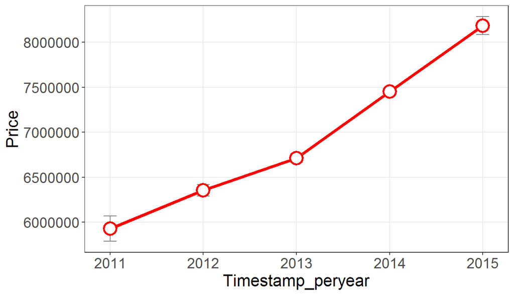

#### Per Month

The monthly plot does not provide a lot of additional information beyond the trend across years. Maybe from 2012 to 2013 there is an effect of month.

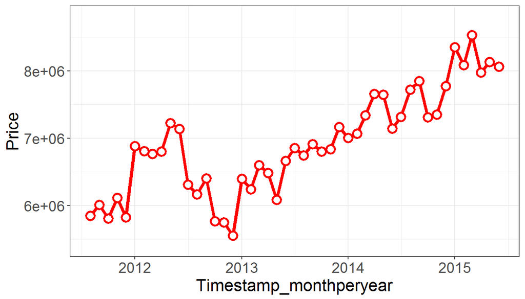

```r
train$year_month <- make_date(year=year(train$timestamp),month=month(train$timestamp))
ggplot(train,aes(x=year_month,y=price_doc))+
  geom_line(stat = "summary", color="red", size=1.5)+
  geom_point(size=3, color="red", fill="white", shape = 21, stat="summary", stroke=1.5)+
  theme_bw()+theme(axis.title = element_text(size=16),axis.text = element_text(size=14))+xlab("Timestamp_monthperyear")+ylab("Price")
```

### Per day

The time series plot is quite spiky so I decided to apply a moving average filter.

```r
tmp <- train %>% group_by(timestamp) %>% summarize(m = mean(price_doc,na.rm=T)) %>% mutate(ma = rollapply(m,width = 20,FUN = mean, align = "right", fill = NA, na.rm = T))
xt <- xts(tmp$ma,as.Date(tmp$timestamp))
names(xt)<-"Price"

dygraph(xt,xlab="Timestamp") %>%
  dySeries("Price", strokeWidth = 3, color="red") %>%
  dyAxis("y", label="Price", valueRange = c(5e+06, 9.5e+06)) %>%
  dyRangeSelector(dateWindow = c("2014-01-01", "2015-01-01")) %>%
  dyOptions(axisLineWidth = 1.5, fillGraph = TRUE, drawGrid = TRUE)
```

[interactive chart not shown]

### Seasonal effects

These plot check the possibility that there might be a trend across the year, e.g. seasonal effects.

#### Per Month

Prices in the first half of the year seem a little higher than in the second half of the year.

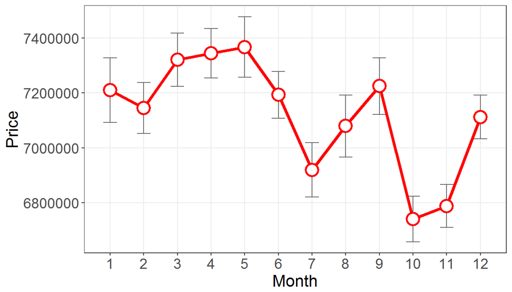

The trend of higher prices in the first half of the year might actually be driven by the year 2012, where we saw an effect of month in the “per month”-Plot above. So excluding this year from the plot we see that the monthly trend is not as pronounced as it was before.

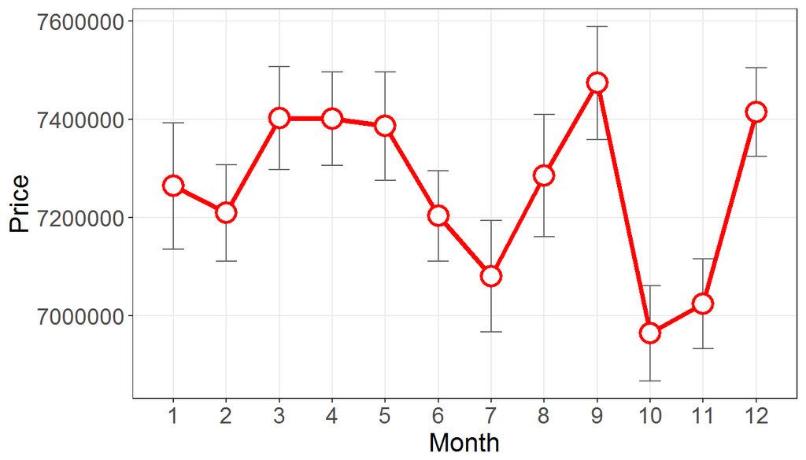

#### Per Day of Month

Within a month the day does not really have an effect on the sale price.

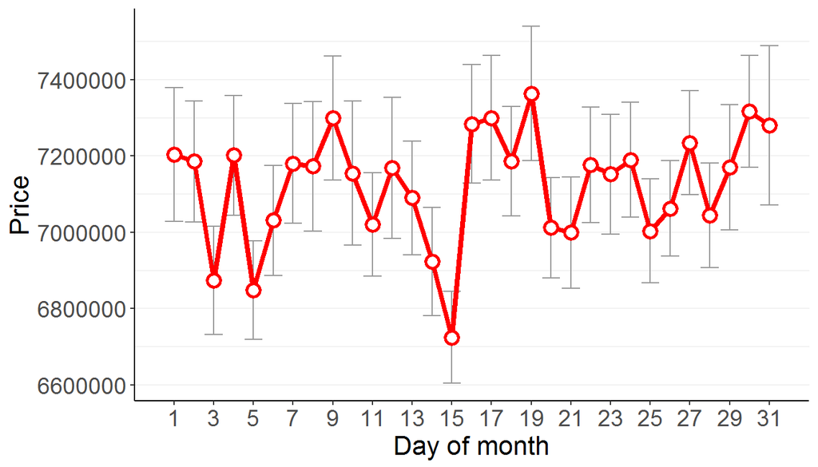

#### Per Day of Week

It seems like selling a house on a weekend (sunday 1, saturday 7) is not a good idea. Thanks for suggesting this idea to [Alexander](https://www.kaggle.com/abogdan).

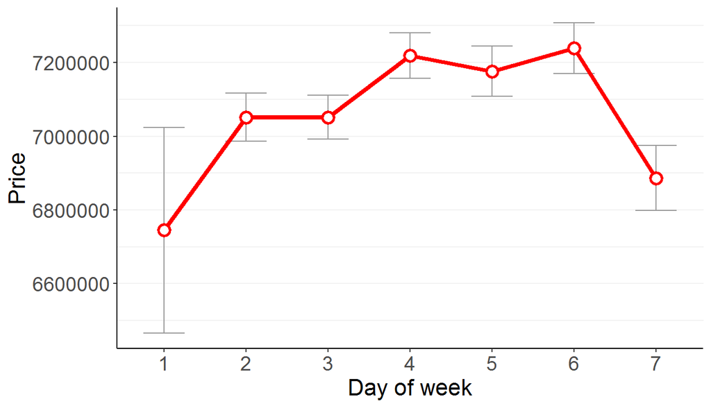

### Total Area

This shows a clear relation, as expected, between the total area and the sale price: The bigger the appartment the higher the sale price. Quite obvious.

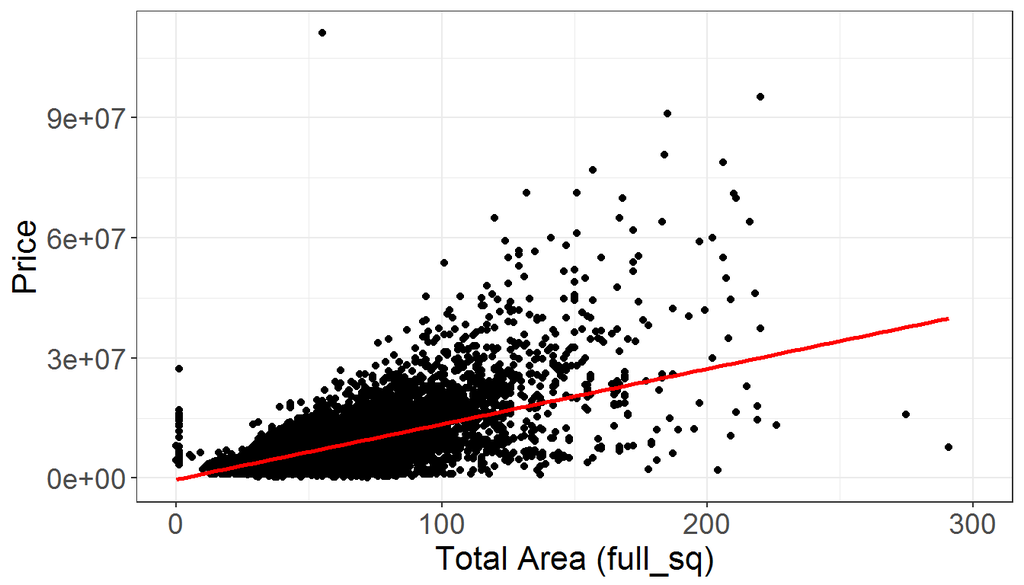

### Living Area

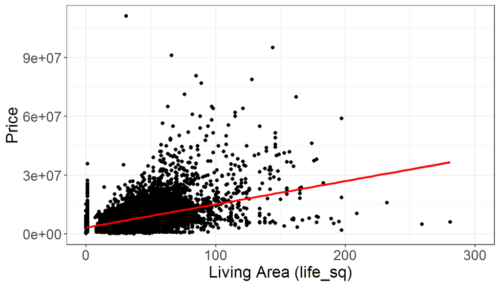

```r
train %>% ggplot(aes(x=life_sq,y=price_doc))+
  geom_point()+
  stat_smooth(aes(x=life_sq,y=price_doc),color="red",method="lm")+
  scale_x_continuous(limits=c(0,300))+
  theme_bw()+theme(axis.title = element_text(size=16),axis.text = element_text(size=14))+xlab("Living Area (life_sq)")+ylab("Price")
```

### Kitchen Area

Again a positive correlation between area and sale price.

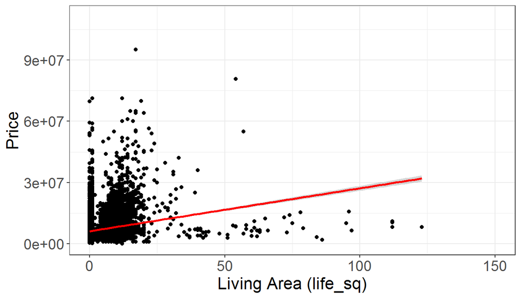

```r
train %>% ggplot(aes(kitch_sq,price_doc))+geom_point()+stat_smooth(color="red",method="lm")+scale_x_continuous(limits=c(0,150))+theme_bw()+theme(axis.title = element_text(size=16),axis.text = element_text(size=14))+xlab("Living Area (life_sq)")+ylab("Price")
```

### Number of Living Rooms

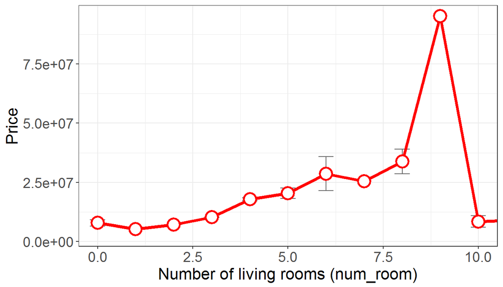

```r
train$num_room <- as.numeric(train$num_room)
ggplot(train,aes(x=num_room,y=price_doc))+geom_errorbar(stat="summary", color="grey40", width=0.4)+geom_line(stat = "summary", color="red", size=1.5)+geom_point(size=5, color="red", fill="white", shape = 21, stat="summary", stroke=1.5)+theme_bw()+theme(axis.title = element_text(size=16),axis.text = element_text(size=14))+xlab("Number of living rooms (num_room)")+ylab("Price")+coord_cartesian(xlim=c(0,10))
```

### Build Year

The build_year variable will need some cleaning, because several values don’t make sense. E.g. there are a lot of build_years with 0 and 1. And on the other hand there are some obvious mistakes, such as 20052009).

#### from 1900

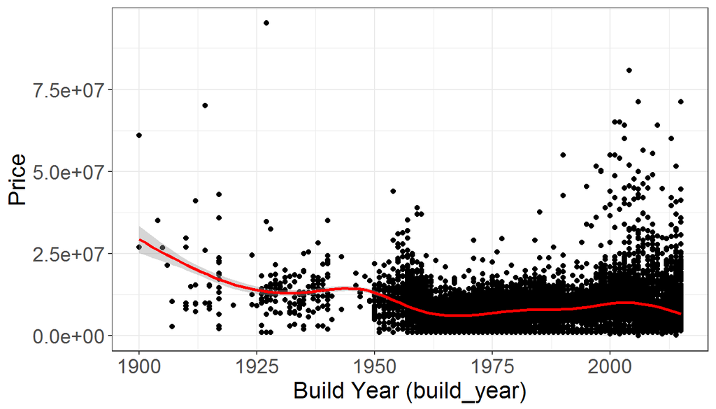

```r
tmp <- filter(train, by > 1000)

ggplot(tmp)+geom_point(aes(x=by,y=price_doc))+stat_smooth(aes(x=by,y=price_doc),color="red")+theme_bw()+theme(axis.title = element_text(size=16),axis.text = element_text(size=14))+scale_x_continuous(limits=c(1900,2015))+xlab("Build Year (build_year)")+ylab("Price")
```

#### from 1950

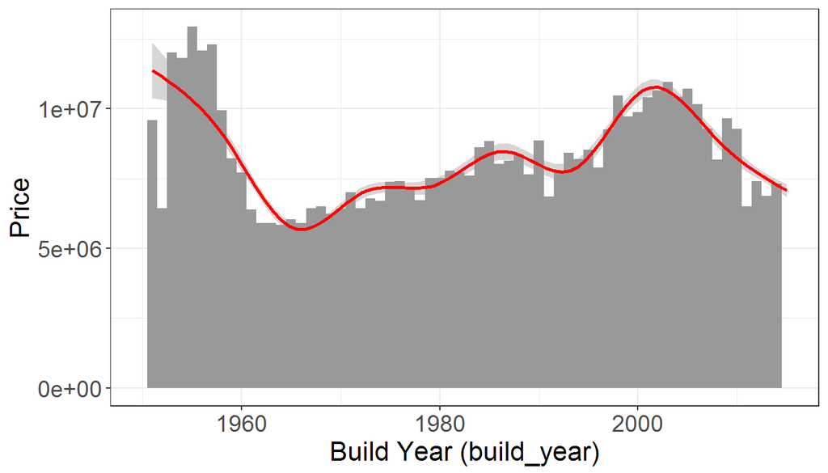

```r
tmp <- filter(train, by > 1950)

ggplot(tmp)+geom_bar(aes(x=by,y=price_doc),width=1,stat="summary", fun.y="mean",fill="grey60")+stat_smooth(aes(x=by,y=price_doc),color="red",se = T)+theme_bw()+theme(axis.title = element_text(size=16),axis.text = element_text(size=14))+scale_x_continuous(limits=c(1950,2015))+xlab("Build Year (build_year)")+ylab("Price")
```

#### Build year 0 and 1

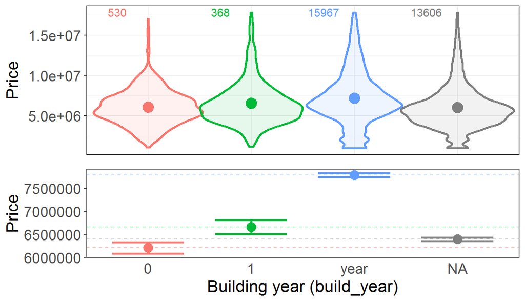

```r
train %>%
  mutate(bynew = ifelse(by<=1,by,"year")) %>%
  cplot("bynew","price_doc",xlab="Building year (build_year)",ylab="Price")
```

### Floor

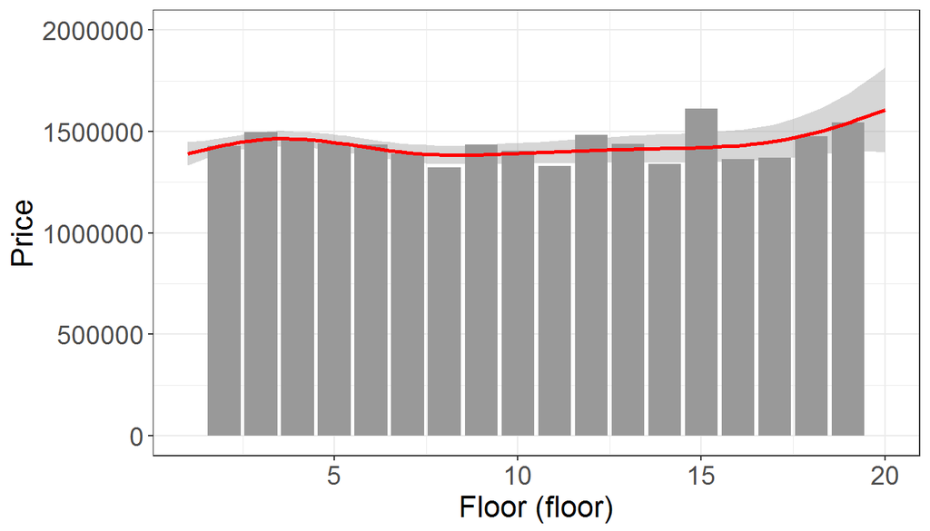

```r
train %>% ggplot()+geom_bar(aes(x=floor,y=price_doc),stat="summary",fun.y="mean",fill="gray60")+stat_smooth(aes(x=floor,y=price_doc),color="red")+scale_x_continuous(limits=c(1,20))+scale_y_continuous(limits=c(0,2000000))+theme_bw()+theme(axis.title = element_text(size=16),axis.text = element_text(size=14))+xlab("Floor (floor)")+ylab("Price")
```

### Max Floor

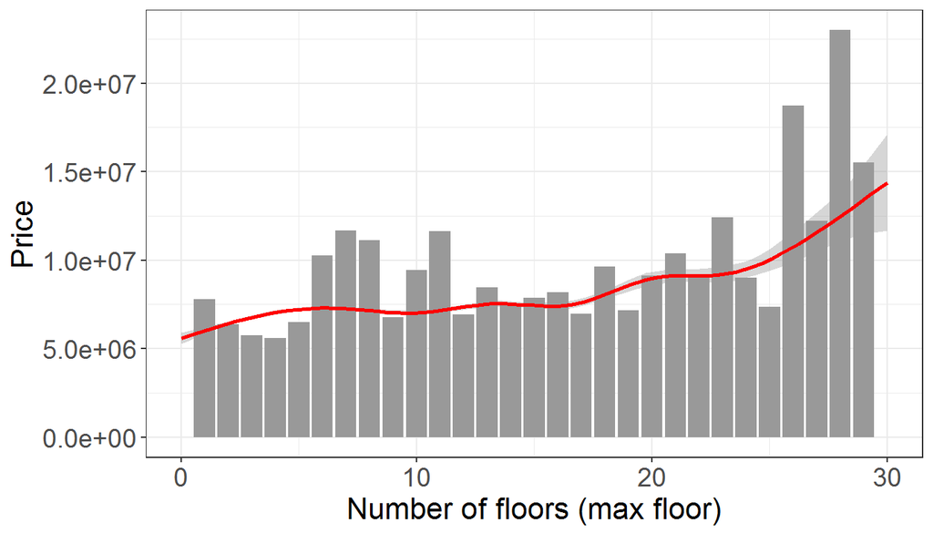

```r
train <- train %>% mutate(max_floor = as.numeric(max_floor))
train %>% ggplot()+geom_bar(aes(x=max_floor,y=price_doc),stat="summary",fun.y="mean", fill="grey60")+stat_smooth(aes(x=floor,y=price_doc), color="red")+theme_bw()+theme(axis.title = element_text(size=16),axis.text = element_text(size=14))+xlab("Number of floors (max floor)")+ylab("Price")+scale_x_continuous(limits=c(0,30))
```

### Floor by MaxFloor

Not only the absolute floor level might have an effect on the sale price, but also the relative floor within a building. Living on the 3rd floor could be different depending if there are 20 floors above you or you can have a coffee on the rooftop :-)

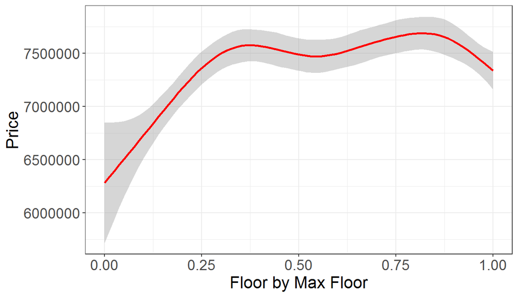

```r
train$flbymax <- as.numeric(train$floor) / as.numeric(train$max_floor)
train %>% ggplot()+stat_smooth(aes(x=flbymax,y=price_doc),color="red")+scale_x_continuous(limits=c(0,1))+
  theme_bw()+theme(axis.title = element_text(size=16),axis.text = element_text(size=14))+xlab("Floor by Max Floor")+ylab("Price")
```

### Appartment State

This variable is coded a little counterintuitively in the data dictionary (1 - worst condition, 4 - best condition)

#### Complete

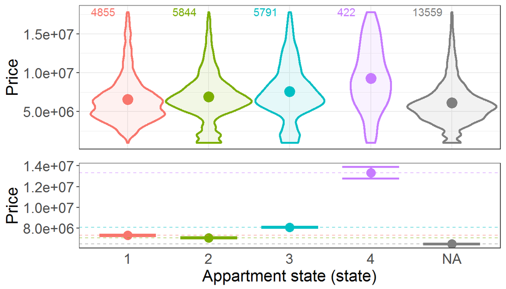

```r
train$state <- as.numeric(train$state)
train$state[train$state==33] <- 3
train %>% cplot("state","price_doc", xlab="Appartment state (state)", ylab="Price")
```

#### Interaction with build_year

There is an interesting interaction between the state of a house and its build_year. For the state variable there are many missing values for OwnerOccupier houses. So I just plot the trend for Investment houses. It is interesting to see that for houses built around 2001 there is an increase in sale price if the house is currently in the best state (4) or in a not so good state (1)

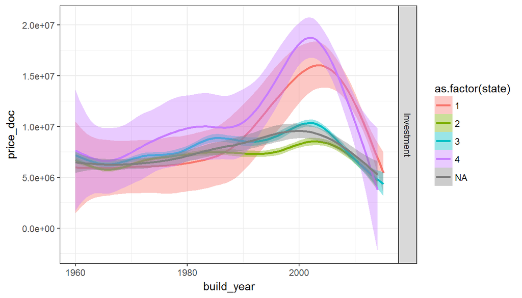

```r
train <- train %>%
  mutate(build_year=as.numeric(build_year),build_year=ifelse(build_year < 1960 | build_year > 2018,NA,build_year))
train %>%
  filter(product_type=="Investment") %>%
  ggplot(aes(x=build_year,y=price_doc,color=as.factor(state),fill=as.factor(state)))+facet_grid(as.factor(product_type)~.)+geom_smooth()+theme_bw()
```

### Wall Material

The data dictionary does not contain more information about the meaning of the individual values. But still there is some variation with sale price.

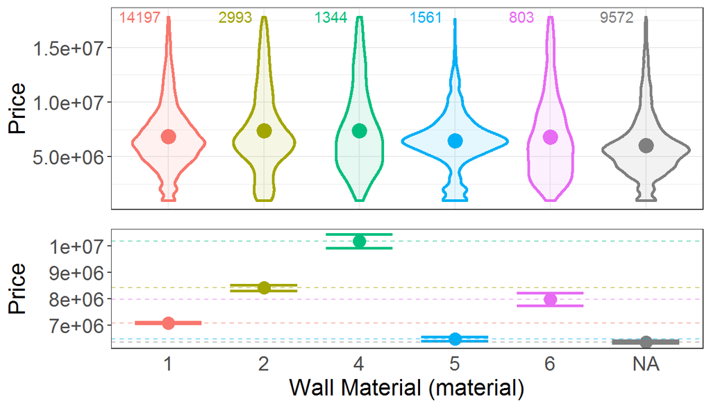

```r
train %>%
  filter(material != 3 | is.na(material)) %>%
  cplot("material","price_doc", xlab="Wall Material (material)", ylab="Price")
```

### Renovated houses

One factor affecting house prices is whether the building has been modernized. To see whether we can get this information for some of the houses I examined the Wall Material by Build Year. One can then examine whether houses with an old build year have a “modern” build material (e.g. 4 or 6). However, looking at the graph this is not/rarely the case.

#### Density

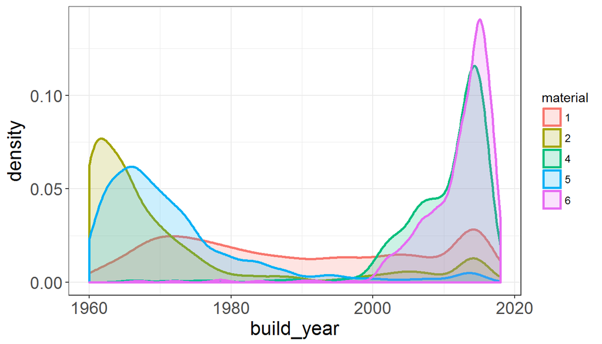

#### Proportions

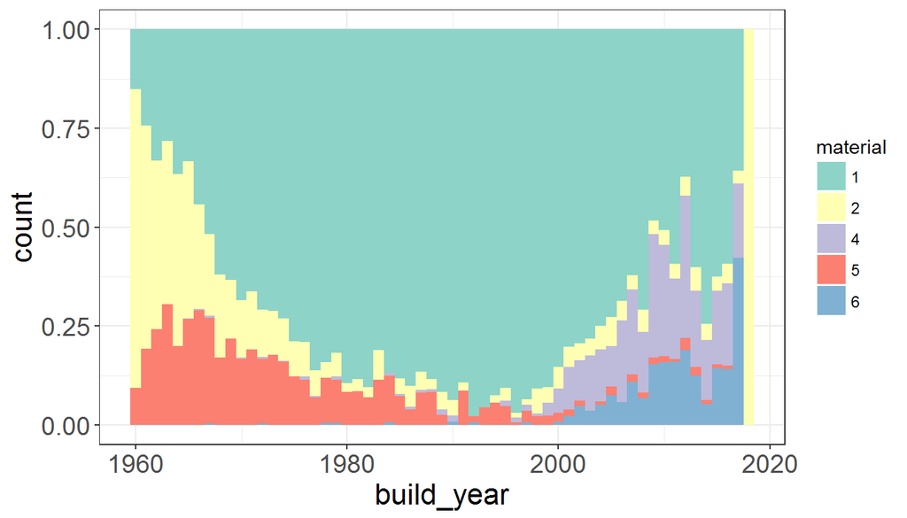

```r
train %>%
  mutate(build_year = as.numeric(build_year), material=as.factor(material)) %>%
  filter((material != 3 | is.na(material)) & (build_year < 2019 & build_year > 1950)) %>%
  ggplot(aes(x=build_year,fill=material))+geom_bar(position="fill",width=1)+theme_bw()+theme(axis.title = element_text(size=16),axis.text = element_text(size=14))+scale_fill_brewer(palette = "Set3")
```

### Product Type

We can see that, property prices are higher for investment sales compared to owner sales. Furthermore the distributions look dissimilar (sale prices might be determined differently).

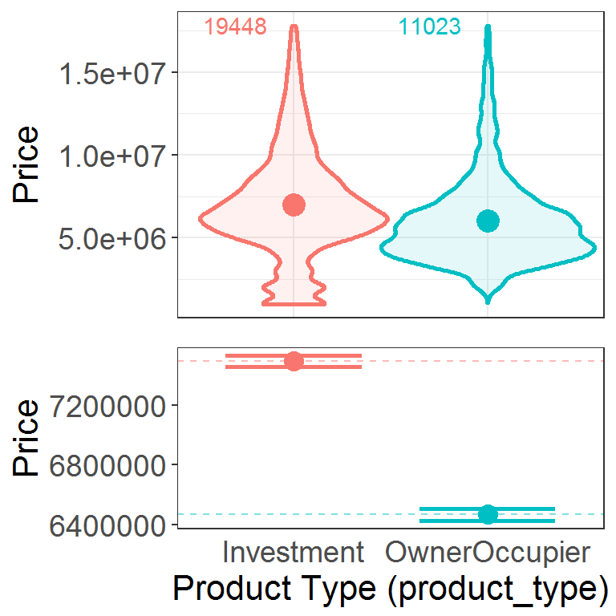

```r
train %>% cplot("product_type","price_doc",xlab="Product Type (product_type)",ylab="Price")
```

### Dealing with cafes & restaurants

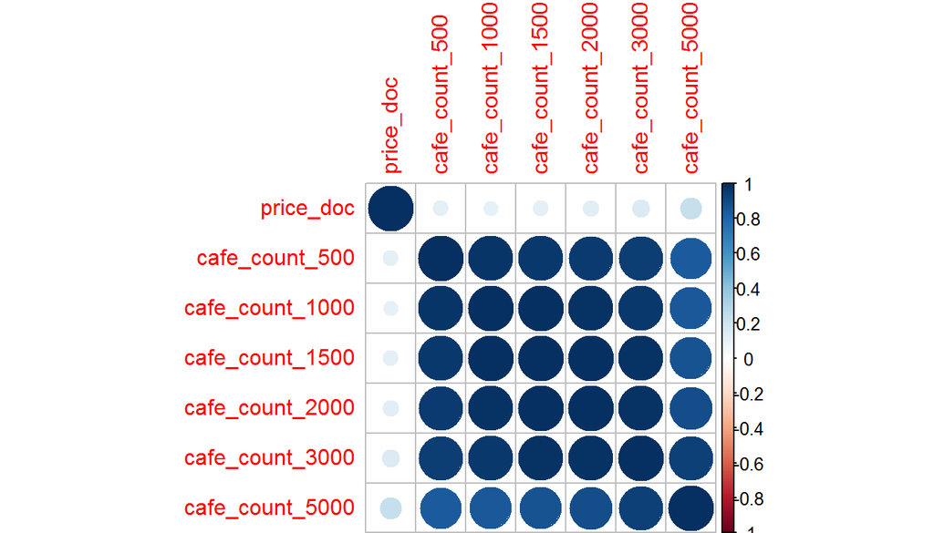

```r
tmp <- train %>% select(c(one_of("price_doc"),matches('cafe_count_[0-9]*$')))
corrplot(cor(tmp,use = "pairwise.complete.obs"))
```

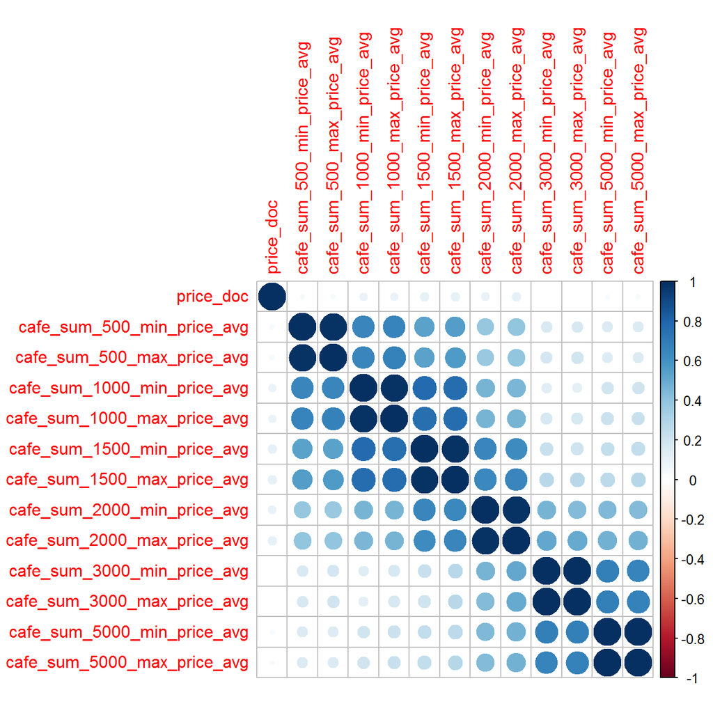

```r
tmp <- train %>% select(c(one_of("price_doc"),starts_with('cafe_sum')))
corrplot(cor(tmp,use = "pairwise.complete.obs"))
```

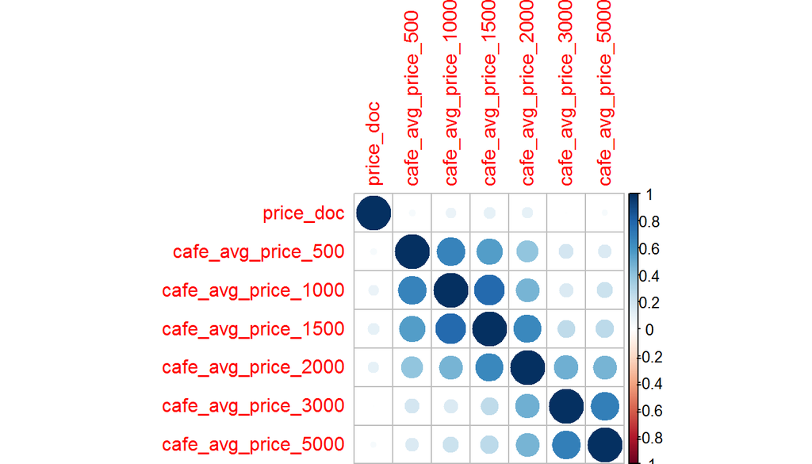

```r
tmp <- train %>% select(c(one_of("price_doc"),starts_with('cafe_avg')))
corrplot(cor(tmp,use = "pairwise.complete.obs"))
```

## Look at distribution of missing values between train and test

Data quality is getting better for the test set. For many variables there are fewer missing values in the test compared to the train set.

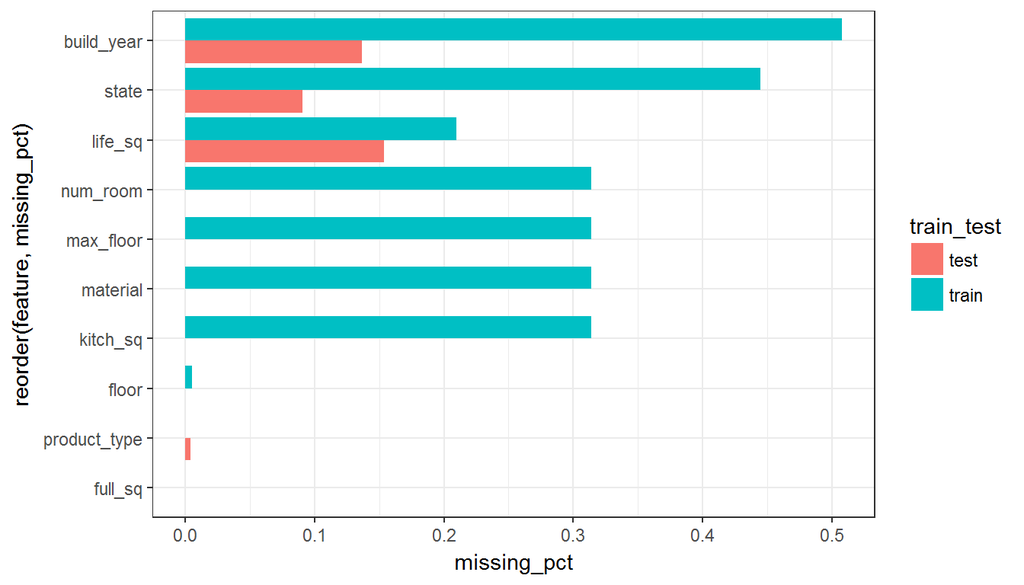

```r
train <- train %>% mutate(train_test = "train")
test <- test %>% mutate(train_test = "test")
full <- bind_rows(train,test)

basic_features <- c("full_sq", "life_sq", "kitch_sq", "num_room", "floor", "max_floor", "material", "build_year", "state", "product_type")

missing_values <- full %>% select(one_of(basic_features,"train_test")) %>% group_by(train_test) %>% summarize_each(funs(sum(is.na(.))/n()))

missing_values <- gather(missing_values, -train_test, key="feature", value="missing_pct")
missing_values %>%
  ggplot(aes(x=reorder(feature,missing_pct),y=missing_pct, fill=train_test)) +
  geom_bar(stat="identity", position="dodge")+
  coord_flip()+theme_bw()
```

## Look at distribution of features between train and test

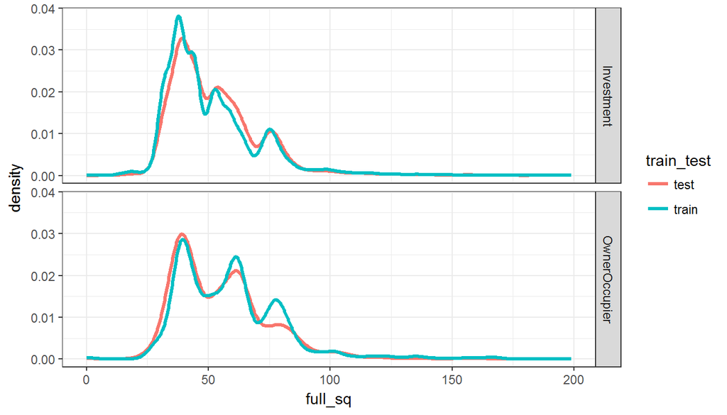

```r
full <- full %>% mutate(product_type=ifelse(is.na(product_type),"Investment",product_type))

full %>% filter(full_sq <= 200) %>% ggplot(aes(x=full_sq)) + stat_density(geom="line",position="identity", aes(group=train_test,color=train_test),size=1.2,na.rm=T)+facet_grid(product_type~.)+theme_bw()
```

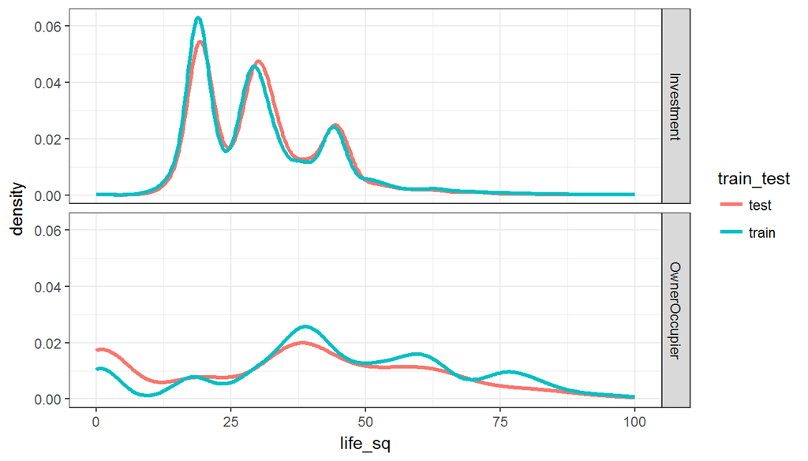

```r
full %>% filter(life_sq <= 100) %>% ggplot(aes(x=life_sq)) + stat_density(geom="line",position="identity", aes(group=train_test,color=train_test),size=1.2,na.rm=T)+facet_grid(product_type~.)+theme_bw()
```

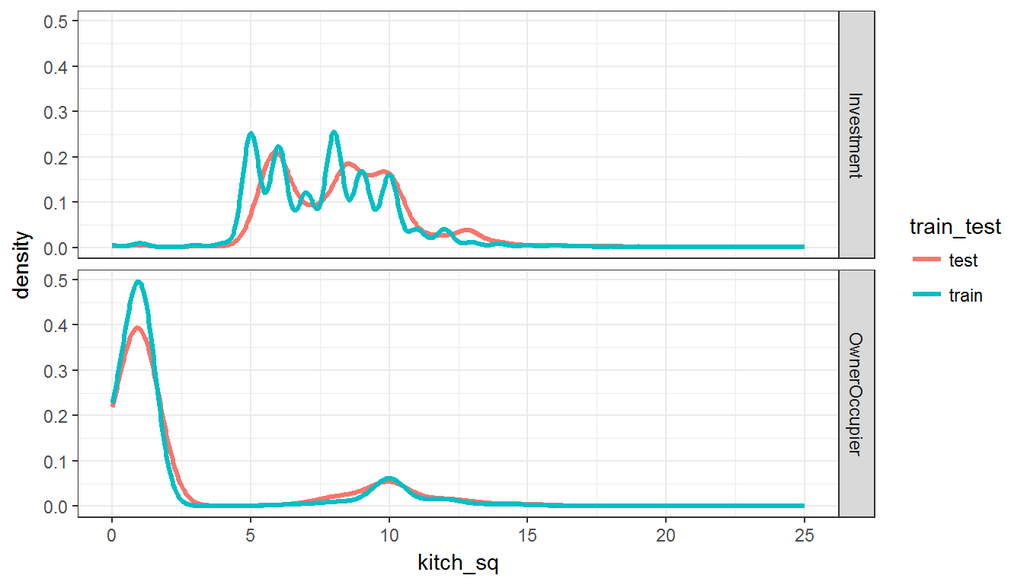

```r
full %>% filter(kitch_sq <= 25) %>% ggplot(aes(x=kitch_sq)) + stat_density(geom="line",position="identity", aes(group=train_test,color=train_test),size=1.2,na.rm=T)+facet_grid(product_type~.)+theme_bw()
```